# Peer-graded Assignment:Prediction Assignmetn Writeup

Christy_Wang

3/15/2020

## Background

```
 Using devices such as Jawbone Up, Nike FuelBand, and Fitbit it is now possible to collect a large amount of data about personal activity relatively inexpensively. These type of devices are part of the quantified self movement – a group of enthusiasts who take measurements about themselves regularly…
```

## Goals of the Project

To predict the manner in which they did the exercise.

**0.Environment preparation**

```r
# set working directory
setwd("~/Desktop/R learning /Coursera")

# Load the required packages
library(caret)
library(rattle)
```

```r
library(rpart)
library(rpart.plot)
library(ggplot2)
library(randomForest)
library(rattle)
library(reshape2)
# import the data
training <- read.csv("pml-training.csv", na.strings = c("NA", " "))
testing <- read.csv("pml-testing.csv", na.strings = c("NA", " "))
```

*The training set has 19622 observations and 160 variables, and the testing dataset has 20 observations and 160 variables.*

**1. Data wrangling**

*1.1 check missing data–delete the variables with >= 80% of the missing data*

```r
is.na(training)
colSums(is.na(training))
missingcol <- c()
for ( i in 1: ncol(training)) {
  pro_missing <- sum(is.na(training[i]))/nrow(training)

  if (pro_missing >= 0.8){
    missingcol <- c(missingcol, i)
  }
}
summary(missingcol)
newtraining <- training[-missingcol]
```

*After removing the variables with a lot of missing data, we now have 93 variables left and remains 19622rows*

*1.2 Remove the variables with no variability*

```r
novar <- nearZeroVar(newtraining)
newtraining_1 <- newtraining[-novar]
```

*1.3 Remove the identificartion variables*

```r
newtraining_2 <- newtraining_1[-(1:5)]
```

*After the data cleaning steps, I have 54 variables and 19622 observations.*

**2. Data spliting**

*In order to get out-of-sample errors, I split the cleaned training set into a training set with 70% proportion, and the 30% for computing the out-of-sample errors*

```r
set.seed(123)

inTrain <- createDataPartition(y=newtraining_2$classe, p=0.7, list=FALSE)
newtraining_2_train <- newtraining_2[inTrain,]
newtraining_2_test <- newtraining_2[-inTrain,]
```

**3. Exploratory Analysis**

*Check the correlation among variables*

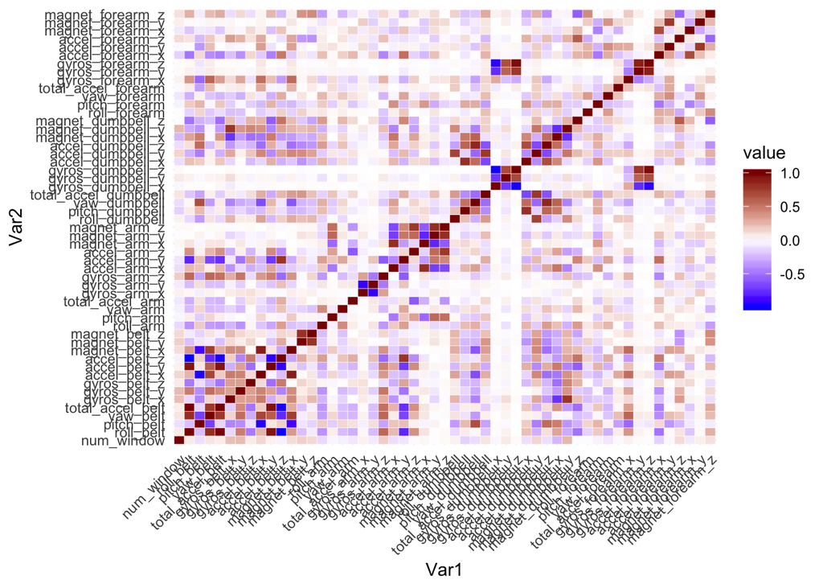

*Accoring to the plot, there are some variables having stronger correlations than that with others. A Principle Component Analysis can be utilized to reduce the number of variables.(However, after the attempts of running with PCA, it will take too long to process data. Therefore, I turned to other methods)*

**4. Prediction Model Selection**

*4.1 random forest*

```r
control <- trainControl(method = "cv", number=5)
modFit.rf <- train(classe ~., data=newtraining_2_train, method="rf", trControl=control)
modFit.rf
```

```
## Random Forest
##
## 13737 samples
##    53 predictor
##     5 classes: 'A', 'B', 'C', 'D', 'E'
##
## No pre-processing
## Resampling: Cross-Validated (5 fold)
## Summary of sample sizes: 10990, 10990, 10989, 10988, 10991
## Resampling results across tuning parameters:
##
##   mtry  Accuracy   Kappa
##    2    0.9943221  0.9928172
##   27    0.9969430  0.9961332
##   53    0.9950500  0.9937384
##
## Accuracy was used to select the optimal model using the largest value.
## The final value used for the model was mtry = 27.
```

*4.2 Decision Tree*

```r
set.seed(123)
control <- trainControl(method="cv", number=5)
fit_rpart <- train(classe ~ ., data=newtraining_2_train, method="rpart", trControl= control)
print(fit_rpart)
```

```
## CART
##
## 13737 samples
##    53 predictor
##     5 classes: 'A', 'B', 'C', 'D', 'E'
##
## No pre-processing
## Resampling: Cross-Validated (5 fold)
## Summary of sample sizes: 10990, 10990, 10988, 10990, 10990
## Resampling results across tuning parameters:
##
##   cp          Accuracy   Kappa
##   0.04292544  0.5386998  0.40581184
##   0.04394263  0.4571563  0.27528096
##   0.11514597  0.3160009  0.04840534
##
## Accuracy was used to select the optimal model using the largest value.
## The final value used for the model was cp = 0.04292544.
```

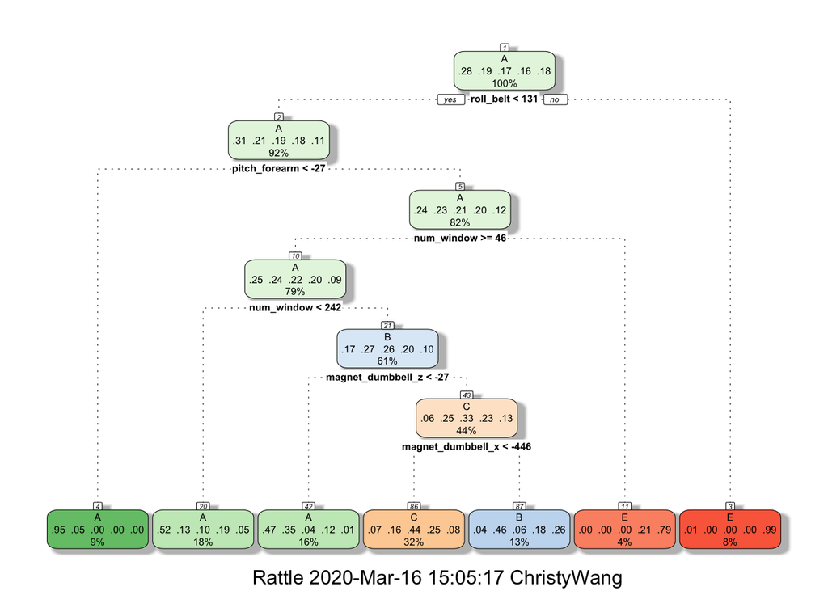

```r
fancyRpartPlot(fit_rpart$finalModel)
```

*4.3 Support Vector Machine*

```r
newtraining_2_train$classe <- as.factor(newtraining_2_train$classe)
library(e1071)
svmfit <- svm(classe~., data=newtraining_2_train, kernel="radial")
```

**Model Comparison**

*4.1 Random Forest*

```r
testrf <- predict(modFit.rf, newtraining_2_test[,-54])
confu.rf <- confusionMatrix(newtraining_2_test$classe,testrf)
confu.rf
```

```
## Confusion Matrix and Statistics
##
##           Reference
## Prediction    A    B    C    D    E
##          A 1674    0    0    0    0
##          B    1 1136    2    0    0
##          C    0    1 1025    0    0
##          D    0    0    1  963    0
##          E    0    0    0    2 1080
##
## Overall Statistics
##
##                Accuracy : 0.9988
##                  95% CI : (0.9976, 0.9995)
##     No Information Rate : 0.2846
##     P-Value [Acc > NIR] : < 2.2e-16
##
##                   Kappa : 0.9985
##
##  Mcnemar's Test P-Value : NA
##
## Statistics by Class:
##
##                      Class: A Class: B Class: C Class: D Class: E
## Sensitivity            0.9994   0.9991   0.9971   0.9979   1.0000
## Specificity            1.0000   0.9994   0.9998   0.9998   0.9996
## Pos Pred Value         1.0000   0.9974   0.9990   0.9990   0.9982
## Neg Pred Value         0.9998   0.9998   0.9994   0.9996   1.0000
## Prevalence             0.2846   0.1932   0.1747   0.1640   0.1835
## Detection Rate         0.2845   0.1930   0.1742   0.1636   0.1835
## Detection Prevalence   0.2845   0.1935   0.1743   0.1638   0.1839
## Balanced Accuracy      0.9997   0.9992   0.9984   0.9989   0.9998
```

*4.2 Decision Tree*

```r
testdt <- predict(fit_rpart, newtraining_2_test[,-54])
confu.dt <- confusionMatrix(newtraining_2_test$classe, testdt)
confu.dt
```

```
## Confusion Matrix and Statistics
##
##           Reference
## Prediction    A    B    C    D    E
##          A 1496   38  138    0    2
##          B  474  390  275    0    0
##          C  166   50  810    0    0
##          D  317  137  471    0   39
##          E   59  190  178    0  655
##
## Overall Statistics
##
##                Accuracy : 0.5694
##                  95% CI : (0.5566, 0.5821)
##     No Information Rate : 0.4268
##     P-Value [Acc > NIR] : < 2.2e-16
##
##                   Kappa : 0.4443
##
##  Mcnemar's Test P-Value : < 2.2e-16
##
## Statistics by Class:
##
##                      Class: A Class: B Class: C Class: D Class: E
## Sensitivity            0.5955  0.48447   0.4327       NA   0.9411
## Specificity            0.9472  0.85256   0.9462   0.8362   0.9177
## Pos Pred Value         0.8937  0.34241   0.7895       NA   0.6054
## Neg Pred Value         0.7587  0.91256   0.7814       NA   0.9915
## Prevalence             0.4268  0.13679   0.3181   0.0000   0.1183
## Detection Rate         0.2542  0.06627   0.1376   0.0000   0.1113
## Detection Prevalence   0.2845  0.19354   0.1743   0.1638   0.1839
## Balanced Accuracy      0.7714  0.66852   0.6894       NA   0.9294
```

*4.3 Support Vector Machine*

```r
svmPred <- predict(svmfit, newtraining_2_test[,-54])
confu.svm <- confusionMatrix(newtraining_2_test$classe,svmPred)
confu.svm
```

```
## Confusion Matrix and Statistics
##
##           Reference
## Prediction    A    B    C    D    E
##          A 1654   11    9    0    0
##          B   74 1031   30    2    2
##          C    2   34  985    5    0
##          D    4    0   92  868    0
##          E    1    3   32   25 1021
##
## Overall Statistics
##
##                Accuracy : 0.9446
##                  95% CI : (0.9385, 0.9503)
##     No Information Rate : 0.2948
##     P-Value [Acc > NIR] : < 2.2e-16
##
##                   Kappa : 0.9298
##
##  Mcnemar's Test P-Value : < 2.2e-16
##
## Statistics by Class:
##
##                      Class: A Class: B Class: C Class: D Class: E
## Sensitivity            0.9533   0.9555   0.8580   0.9644   0.9980
## Specificity            0.9952   0.9775   0.9913   0.9807   0.9875
## Pos Pred Value         0.9881   0.9052   0.9600   0.9004   0.9436
## Neg Pred Value         0.9808   0.9899   0.9665   0.9935   0.9996
## Prevalence             0.2948   0.1833   0.1951   0.1529   0.1738
## Detection Rate         0.2811   0.1752   0.1674   0.1475   0.1735
## Detection Prevalence   0.2845   0.1935   0.1743   0.1638   0.1839
## Balanced Accuracy      0.9742   0.9665   0.9247   0.9726   0.9927
```

**5. Prediction on Testing set** *Based on the results from the above models, Random Forest has the best performance with accuracy rate 99.9% on tested-training set (Decision tree: 56.9%, Support Vectir Machine: 94.5% ). So I will use Random Forest on the test set and estimated that I will get 0.1% of error rate.*

```r
predictest<- predict(modFit.rf, testing)
predictest
```

```
##  [1] B A B A A E D B A A B C B A E E A B B B
## Levels: A B C D E
```

**The End**